# Learn by Building 2: Data Visualization

Jeremia Widyanto

May 22, 2022

# 1 Introduction

## 1.1 Tujuan Pelatihan

Tujuan utama dari kursus ini adalah untuk memberikan pengenalan yang komprehensif untuk data visualization dengan menggunakan data yang ada.

Visualisasi Data adalah tampilan data dan informasi dalam bentuk grafis atau visual. Contoh bentuk grafis atau visualnya seperti peta, diagram / grafik, bagan / struktur. Salah satu kegunaan visualisasi data adalah untuk mempermudah komunikasi antara penyedia data (provider) dengan pengguna data (reciever/user). Dimana penyedia akan memberikan informasi - informasi penting sesuai dengan kepentingan / bisnisnya, yang perlu diperhatikan dalam menampilkan data nya adalah bila pengguna data dapat memahami visualisasi tersebut dengan mudah dimengerti dan secara cepat.

# 2 Explanatory Data Analysis

## 2.1 Import Data & Library

```r
library(ggplot2)
library(scales)
library(carData)
library(dplyr)
library(ggridges)
data(Salaries,
     package = "carData")
```

Data yang digunakan menggunakan Packages ‘carData’, dengan data Salaries:

- rank: Jenis jabatannya
- discipline: Penilaian dari Discipline
- yrs.since.phd: Lama tahun sejak menjadi PhD
- yrs.service: Lama tahun mengajar
- sex: Jenis Kelamin
- salary: Gaji nya

Melihat data dari ‘Salaries’:

```r
Salaries
```

| rank | discipline | yrs.since.phd | yrs.service | sex | salary |
| --- | --- | --- | --- | --- | --- |
| Prof | B | 19 | 18 | Male | 139750 |
| Prof | B | 20 | 16 | Male | 173200 |
| AsstProf | B | 4 | 3 | Male | 79750 |
| Prof | B | 45 | 39 | Male | 115000 |
| Prof | B | 40 | 41 | Male | 141500 |
| AssocProf | B | 6 | 6 | Male | 97000 |
| Prof | B | 30 | 23 | Male | 175000 |
| Prof | B | 45 | 45 | Male | 147765 |
| Prof | B | 21 | 20 | Male | 119250 |
| Prof | B | 18 | 18 | Female | 129000 |

[output cut: 387 more lines]

Melihat sturktur data dari ‘Salaries’:

```r
str(Salaries)
```

```
#> 'data.frame':    397 obs. of  6 variables:
#>  $ rank         : Factor w/ 3 levels "AsstProf","AssocProf",..: 3 3 1 3 3 2 3 3 3 3 ...
#>  $ discipline   : Factor w/ 2 levels "A","B": 2 2 2 2 2 2 2 2 2 2 ...
#>  $ yrs.since.phd: int  19 20 4 45 40 6 30 45 21 18 ...
#>  $ yrs.service  : int  18 16 3 39 41 6 23 45 20 18 ...
#>  $ sex          : Factor w/ 2 levels "Female","Male": 2 2 2 2 2 2 2 2 2 1 ...
#>  $ salary       : int  139750 173200 79750 115000 141500 97000 175000 147765 119250 129000 ...
```

> Terdiri dari 397 observasi dan 6 variables, Tipe data yang digunakan juga sudah sesuai.

## 2.2 Missing Data

Melakukan cek Missing Data dari ‘Salaries’:

```r
colSums(is.na(Salaries))
```

```
#>          rank    discipline yrs.since.phd   yrs.service           sex
#>             0             0             0             0             0
#>        salary
#>             0
```

> Tidak ada missing value, sehingga data sudah bisa digunakan untuk tahap selanjutnya.

## 2.3 Subseting Data

Mengganti keterangan di Rank, sehingga tidak berupa singkatan.

```r
Salaries_clean <- Salaries %>%
  mutate(rank = ifelse(rank == "Prof", "Full Professor",
                       ifelse(rank == "AsstProf", "Assistant Professor", "Associate Professor")))
Salaries_clean
```

| rank | discipline | yrs.since.phd | yrs.service | sex | salary |
| --- | --- | --- | --- | --- | --- |
| Full Professor | B | 19 | 18 | Male | 139750 |
| Full Professor | B | 20 | 16 | Male | 173200 |
| Assistant Professor | B | 4 | 3 | Male | 79750 |
| Full Professor | B | 45 | 39 | Male | 115000 |
| Full Professor | B | 40 | 41 | Male | 141500 |
| Associate Professor | B | 6 | 6 | Male | 97000 |
| Full Professor | B | 30 | 23 | Male | 175000 |
| Full Professor | B | 45 | 45 | Male | 147765 |
| Full Professor | B | 21 | 20 | Male | 119250 |
| Full Professor | B | 18 | 18 | Female | 129000 |

[output cut: 387 more lines]

# 3 Data Visualization

1. Melihat Jumlah Data dari variable ‘rank’, dan melihat urutan datanya dari yang tertinggi dengan menggunakan Diagram Batang atau ‘geom_bar’:

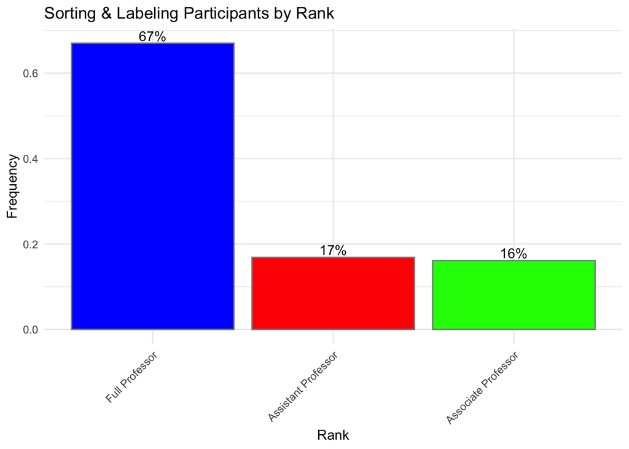

```r
plot_bar <- Salaries_clean %>%
  count(rank) %>%
  mutate(pct = n / sum(n),
         pctlabel = paste0(round(pct*100), "%"))

ggplot(plot_bar,
       aes(x = reorder(rank, -pct),
           y = pct)) +
  geom_bar(stat = "identity",
           fill = rainbow(3),
           color = "azure4") +
  geom_text(aes(label = pctlabel),
                vjust = -0.25) +
  theme_minimal() +
  labs(x = "Rank",
       y = "Frequency",
       title = "Sorting & Labeling Participants by Rank") +
  theme(axis.text.x = element_text(angle = 45,
                                   hjust = 1))
```

Membuat Table rank:

```r
Salaries_col <- as.data.frame(table(Salaries_clean$rank))
Salaries_col
```

| Var1 | Freq |
| --- | --- |
| Assistant Professor | 67 |
| Associate Professor | 64 |
| Full Professor | 266 |

Diagram Batang untuk menggunakan ‘geom_col’ dan mengubah sumbu x dan sumbu y nya.

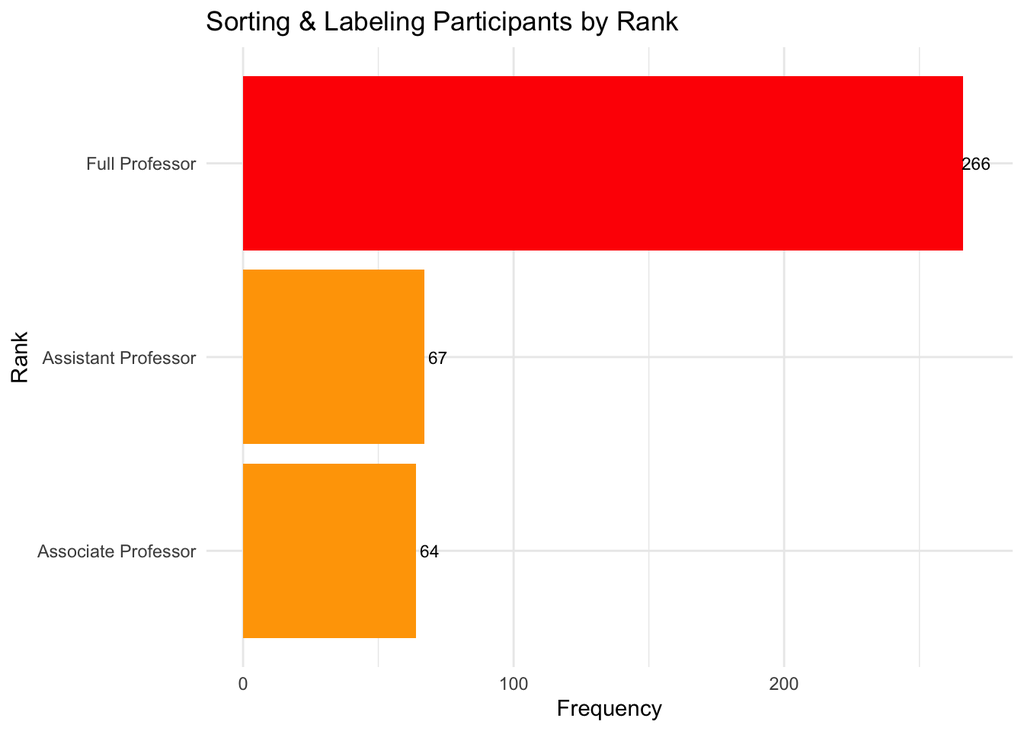

```r
ggplot(Salaries_col,
       aes(x = Freq,
           y = reorder(Var1, Freq))) +
  geom_col(aes(fill = Freq)) +
  scale_fill_gradient(low = "orange", high = "red") +
  geom_text(aes(label = Freq),
            color = "black",
            size = 3,
            nudge_x = 5) +
  theme_minimal() +
  theme(legend.position = "none") +
  labs(x = "Frequency",
       y = "Rank",
       title = "Sorting & Labeling Participants by Rank")
```

Insight yang dapat diambil dari visualisasi diatas: > Urutan dari participant berdasarkan rank adalah - Full Professor berjumlah 266 orang (67%) - Assistant Professor berjumlah 67 orang (17%) - Associate Professor berjumlah 64 orang (16%)

2. Melihat grafik yang menampilkan data rata-rata gaji berdasarkan jabatan akademiknya

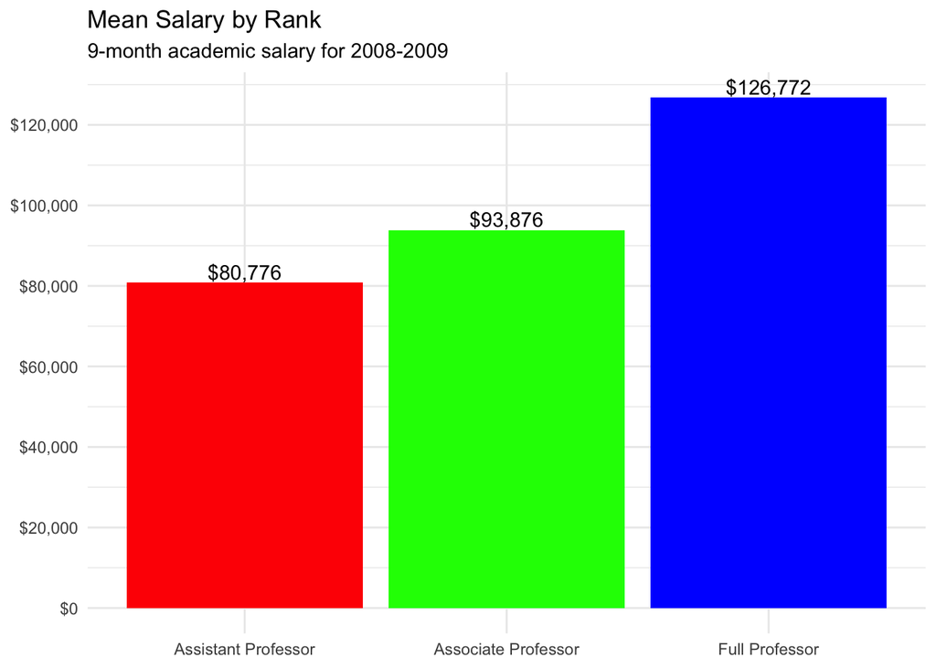

```r
plot_bar1 <- Salaries_clean %>%
  group_by(rank) %>%
  dplyr::summarize(mean_salary = mean(salary))

ggplot(plot_bar1,
       aes(x = factor(rank,
                      labels = c("Assistant Professor", "Associate Professor", "Full Professor")),
           y = mean_salary)) +
  geom_bar(stat = "identity",
           fill = rainbow(3)) +
  geom_text(aes(label = dollar(mean_salary)),
            vjust = -0.25) +
  scale_y_continuous(breaks = seq(0, 130000, 20000),
                     label = dollar) +
  theme_minimal() +
  labs(title = "Mean Salary by Rank",
       subtitle = "9-month academic salary for 2008-2009",
       x = NULL,
       y = NULL)
```

Insight yang dapat diambil: > Range / kisaran rata- rata gaji dari jabatan Assistant Professor adalah $80,776

> Range / kisaran rata- rata gaji dari jabatan Associate Professor adalah $93,876

> Range / kisaran rata- rata gaji dari jabatan Full Professor adalah $126,772
3. Melihat distribusi data gaji berdasarkan jabatan yang dikelompokkan, menggunakan plot densitas kernel:

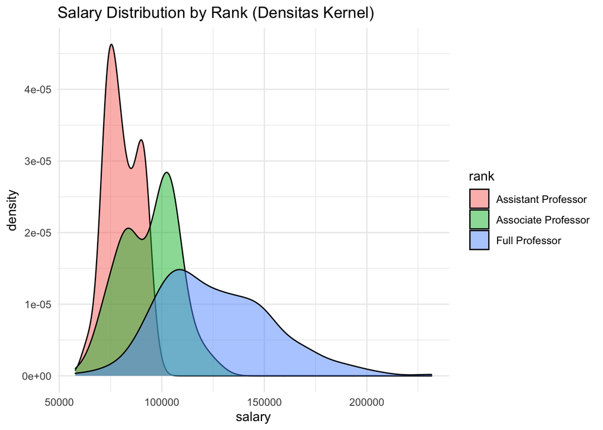

```r
ggplot(Salaries_clean,
       aes(x = salary,
           fill = rank)) +
  geom_density(alpha = 0.5) +
  theme_minimal() +
  labs(title = "Salary Distribution by Rank (Densitas Kernel)")
```

Opsi ‘alpha’ dalam plot densitas menjadi sebagian transparan sehingga kita dapat melihat bagian yang bertumpukan.

Insight yang dapat diambil: > Bahwa gaji akan meningkat sesuai jabatannya

4. Melihat distribusi data gaji berdasarkan jabatan yang dikelompokkan, menggunakan boxplot:

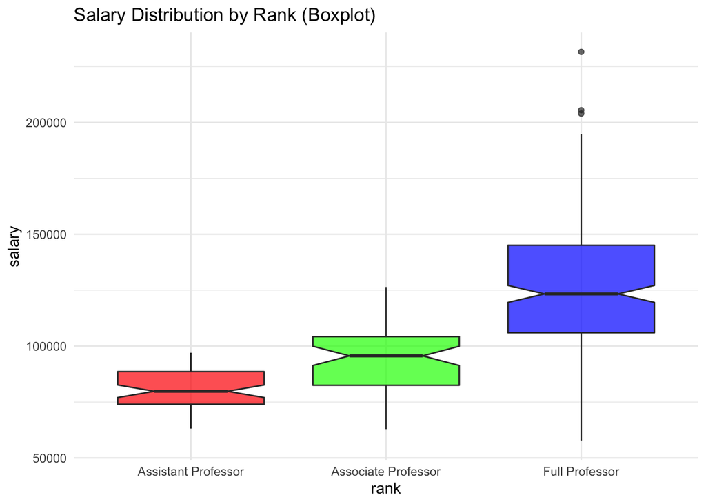

```r
ggplot(Salaries_clean,
       aes(x = rank,
           y = salary)) +
  geom_boxplot(notch = TRUE,
               fill = rainbow(3),
               alpha = 0.7) +
  theme_minimal() +
  labs(title = "Salary Distribution by Rank (Boxplot)")
```

5. Melihat data rata-rata gaji berdasarkan jabatan dan jenis kelamin menggunakan Diagram Garis.

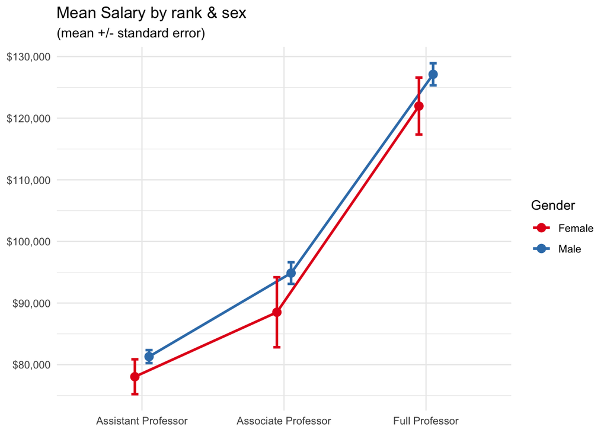

```r
plot_line1 <- Salaries_clean %>%
  group_by(rank, sex) %>%
  dplyr::summarize(n = n(),
                   mean = mean(salary),
                   sd = sd(salary),
                   se = sd/sqrt(n),
                   ci = qt(0.975, df = n - 1) * sd / sqrt(n))

pd <- position_dodge(0.2)

ggplot(plot_line1,
       aes(x = factor(rank,
                      labels = c("Assistant Professor", "Associate Professor", "Full Professor")),
           y = mean,
           group = sex,
           color = sex)) +
  geom_point(position = pd,
             size = 3) +
  geom_line(position = pd,
            size = 1) +
  geom_errorbar(aes(ymin = mean - se,
                    ymax = mean + se),
                width = 0.1,
                position = pd,
                size = 1) +
  scale_y_continuous(labels = scales::dollar) +
  scale_color_brewer(palette = "Set1") +
  theme_minimal() +
  labs(title = "Mean Salary by rank & sex",
       subtitle = "(mean +/- standard error)",
       x = NULL,
       y = NULL,
       color = "Gender")
```

Insight yang dapat diambil: > Grafik diatas dapat menampilkan data rata-rata gaji dari setiap jabatan dan gender, dengan tambahan +- dari standard error nya.

6. Melihat distribusi gaji berdasarkan jabatan menggunakan plot strip dan jitter.

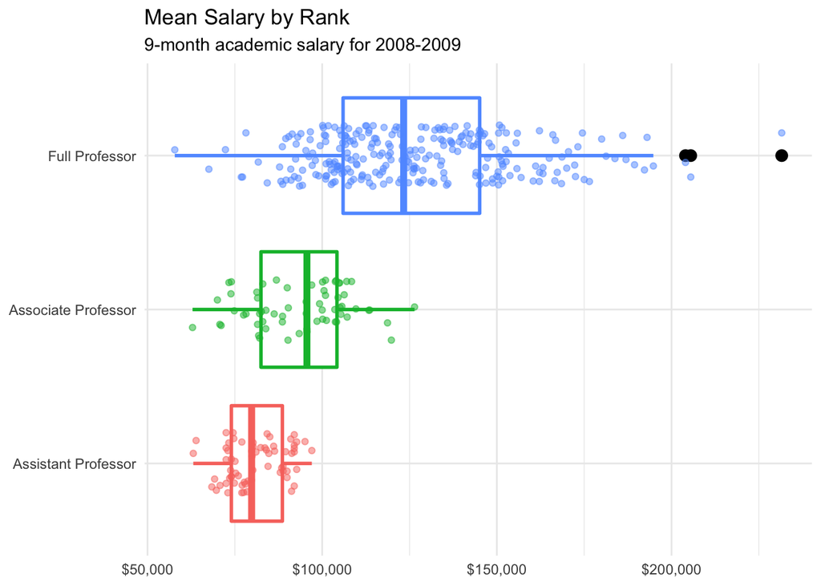

```r
ggplot(Salaries_clean,
       aes(x = factor(rank,
                      labels = c("Assistant Professor", "Associate Professor", "Full Professor")),
           y = salary,
           color = rank)) +
  geom_boxplot(size = 1,
               outlier.alpha = 1,
               outlier.color = "black",
               outlier.size = 3) +
  geom_jitter(alpha = 0.5,
              width = 0.2) +
  scale_y_continuous(label = dollar) +
  labs(title = "Mean Salary by Rank",
       subtitle = "9-month academic salary for 2008-2009",
       x = NULL,
       y = NULL) +
  theme_minimal() +
  theme(legend.position = "none") +
  coord_flip()
```

7. Melihat hubungan data antara salary, years since PhD, rank, dan jenis kelamin

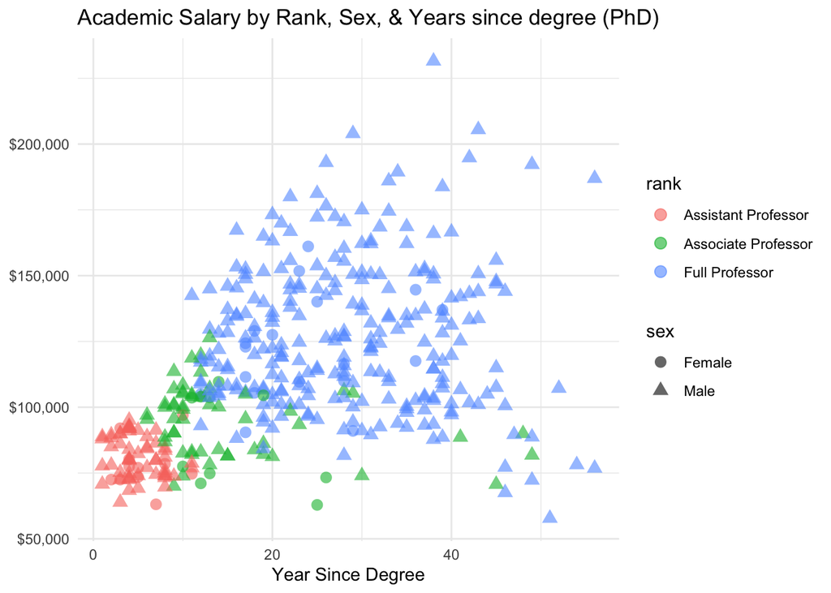

```r
ggplot(Salaries_clean,
       aes(x = yrs.since.phd,
           y = salary,
           color = rank,
           shape = sex)) +
  geom_point(size = 3,
             alpha = 0.6) +
  scale_y_continuous(labels = scales::dollar) +
  theme_minimal() +
  labs(title = "Academic Salary by Rank, Sex, & Years since degree (PhD)",
       x = "Year Since Degree",
       y = NULL)
```

Insight yang dapat diambil: > Grafik diatas dapat menampilkan distribusi data gaji dari setiap jabatan, gender, dan lamanya tahun setelah mendapatkan gelar PhD.

8. Melihat hubungan antara tahun sejak mendapatkan gelar PhD dan gaji dan masa kerja.

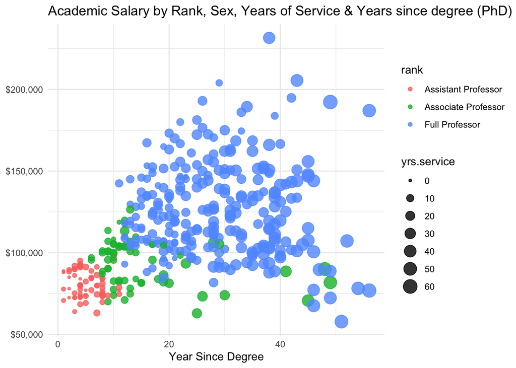

```r
ggplot(Salaries_clean,
       aes(x = yrs.since.phd,
           y = salary,
           color = rank,
           size = yrs.service)) +
  geom_point(alpha = 0.8) +
  scale_y_continuous(labels = scales::dollar) +
  theme_minimal() +
  labs(title = "Academic Salary by Rank, Sex, Years of Service & Years since degree (PhD)",
       x = "Year Since Degree",
       y = NULL)
```

Insight yang dapat diambil: > Grafik diatas dapat menampilkan distribusi data gaji dari setiap jabatan, masa kerja, dan lamanya tahun setelah mendapatkan gelar PhD.

# 4 Conclusion

Data Visualization dapat berguna dalam menampilkan informasi dan data secara menarik. Sehingga selain dapat beberapa insight, data visualization ini berguna untuk mengambil keputusan untuk tahapan selanjutnya.